# Homework 1

Barrett Bryson

1/7/2015

**Excercise 1**

```r
sample(1:6,10,replace=TRUE)+sample(1:6,10,replace=TRUE)
```

```
##  [1] 11  9  8  8  5 10  6 11  3  8
```

**Excercise 2**

```r
integrate(dnorm, -1, 1);
```

```
## 0.6826895 with absolute error < 7.6e-15
```

```r
integrate(dnorm, -2, 2);
```

```
## 0.9544997 with absolute error < 1.8e-11
```

```r
integrate(dnorm, -3, 3)
```

```
## 0.9973002 with absolute error < 9.3e-07
```

**Excercise 3**

```r
1 - pnorm(130,100,15)
```

```
## [1] 0.02275013
```

**Excercise 4**

```r
pexp(200, .0001)
```

```
## [1] 0.01980133
```

**Excercise 5**  
Quantitative: gpa, height, pulse, childrank, numchildren, haircut, randomnim, speedtickets, cds, hourssleep, cupscoffee  
Continous: childrank, numchildren, haircut, randomnum, speedtickets, cds, cupscoffee  
Discrete: gpa, height, pulse, hourssleep

**Excercise 6**  
Overall Population

```
## region
##                   Rural    Suburban       Urban
## 0.003571429 0.178571429 0.678571429 0.139285714
```

**Excercise 7**

```r
prop.table(xtabs(~ momhandedness, data = ss))
```

```
## momhandedness
##                       L           R
## 0.007142857 0.057142857 0.935714286
```

```r
cleanedss = droplevels(subset(ss, selfhandedness!=""))
twicecleanedss = droplevels(subset(cleanedss, momhandedness!=""))
```

**Excercise 8**  
The first is useful as a display of just the raw numbers with the inclusion of blank data.  
The second gives the probality of each combination ex: mom with lefthandedness, childness with righthandedness still including blank data.  
The third and fourth are the same as the first two however blank data has been removed.  
The fifth and sixth compare probabilities only in respect to rows or columns respectively.  
The sixth command would seem the most usful as shows the probability that the child has the same dominant hand as the mother.

**Excercise 9**

```
##               momhandedness
## selfhandedness         L         R
##              L 0.0625000 0.1145038
##              R 0.9375000 0.8854962
```

As shown above the data would seem to suggest that if your mother is right handed you have a higher chance of being lefthanded.

```
##               momhandedness
## selfhandedness   L   R
##              L   1  30
##              R  15 232
```

However this is more likely due to the small size of lefthanded people more than actual causation.

**Excercise 10**

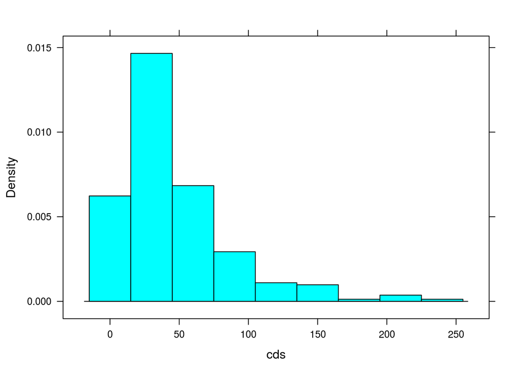

```r
histogram(~cds,data=subset(ss,cds<250))
```

**Excercise 11**

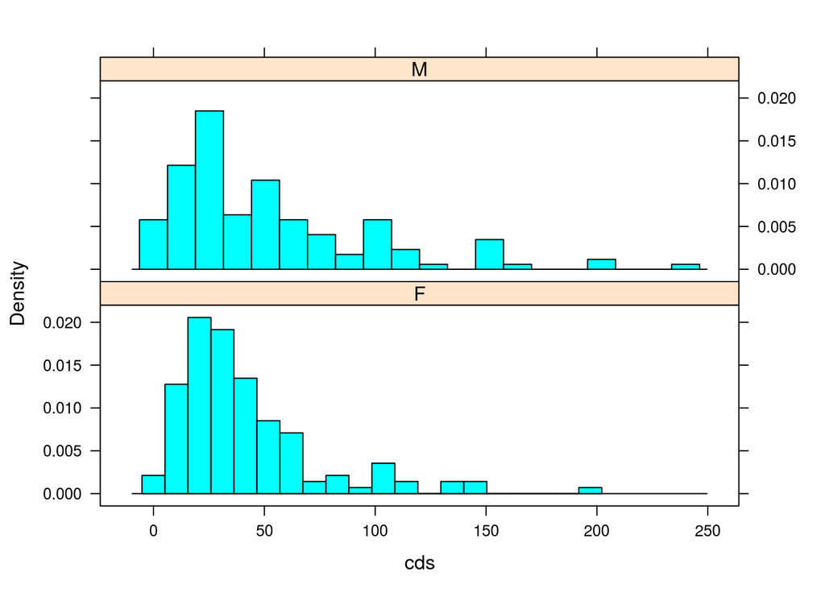

```r
histogram(~cds | gender, data=subset(ss,cds<250), n=20, layout=c(1,2))
```

If there was no association between gender and number of cds owned then the two above graphs should appear to be relatively similar. Note however that the males graph has a larger spread of cd ownership.

**Excercise 12**

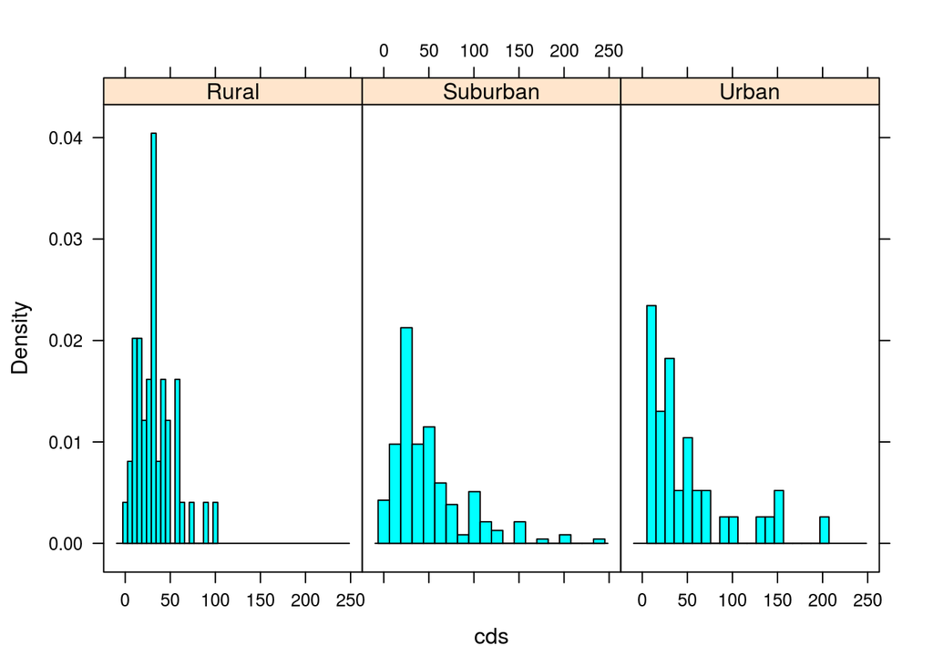

**Excercise 13**

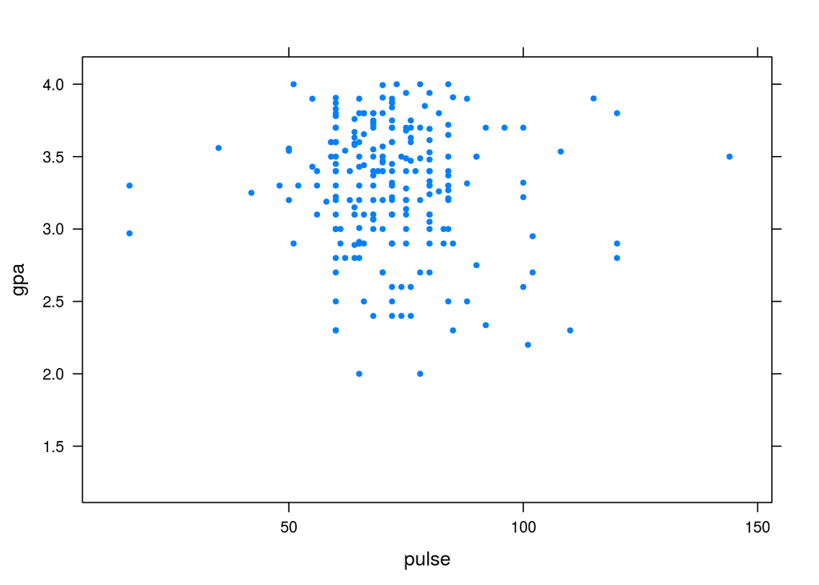

This graph compares the subjects gpas to their pulse. It demonstrates no association. This is determined in that any given gpa has a wide variety of pulse values that match up and vice versa.